# Impact of COVID 19 on diet

Stat425 Final Project

Hyunjoon Rhee

3/21/2021

## Introduction

December 19th, there was a first confirmed case of COVID-19 from Wuhan, China. Since then highly infectious COVID-19 has transferred the virus all over the world in short time. It has been more than a year since the pandemic has started. People are living a different life, comparing the before and after the pandemic started. One of the major difference that the people are experiencing is the diet. The way people are eating has changed ever since. The restrictions that people were given prevented people from dining outside and started to consume food in home more. Additional to such phenomenon, there must have been more changes toward the dietary patterns of people.

In this project, I am going to analyze and compare the energy consumption level and the active cases of COVID-19, in order to see the relationship between those two.

The data is obtained from Kaggle(2021). The data shows the energy intake level from various products in 170 different countries. The data is composed of 32 columns of different variables and 170 rows. The meaning of each variables are explained in Kaggle, and is summarized below:

- Country(Categorical): Countries around the world
- Alcoholic Beverages(Numeric): Percentage of energy intake (kcal) from alcoholic beverages
- Animal Products(Numeric): Percentage of energy intake (kcal) from animal products
- Animal Fats(Numeric): Percentage of energy intake (kcal) from animal fats
- Aquatic Products, Other(Numeric): Percentage of energy intake (kcal) from aquatic product
- Cereals - Excluding Beer(Numeric): Percentage of energy intake (kcal) from cereal - excluding beer
- Eggs(Numeric): Percentage of energy intake (kcal) from eggs
- Fish, Seafood(Numeric): Percentage of energy intake (kcal) from fish, seafood
- Fruits - Excluding Wine(Numeric): Percentage of energy intake (kcal) from fruits - excluding wine
- Meat(Numeric): Percentage of energy intake (kcal) from meat
- Milk - Excluding Butter(Numeric): Percentage of energy intake (kcal) from milk - excluding butter
- Miscellaneous(Numeric): Percentage of energy intake (kcal) from miscellaneous
- Offals(Numeric): Percentage of energy intake (kcal) from offals
- Oilcrops(Numeric): Percentage of energy intake (kcal) from oilcrops
- Pulses(Numeric): Percentage of energy intake (kcal) from pulses
- Spices(Numeric): Percentage of energy intake (kcal) from spices
- Starchy Roots(Numeric): Percentage of energy intake (kcal) from starchy roots
- Stimulants(Numeric): Percentage of energy intake (kcal) from stimulants
- Sugar Crops(Numeric): Percentage of energy intake (kcal) from sugar crops
- Sugar & Sweeteners(Numeric): Percentage of energy intake (kcal) from sugar and sweeteners
- Treenuts(Numeric): Percentage of energy intake (kcal) from treenuts
- Vegetable Products(Numeric): Percentage of energy intake (kcal) from vegetal products
- Vegetable oils(Numeric): Percentage of energy intake (kcal) from vegetable oils
- Vegetables(Numeric): Percentage of energy intake (kcal) from vegetables
- Obesity(Numeric): Obesity rate (%)
- Undernourished(Numeric): Undernourished rate (%)
- Confirmed(Numeric): Percentage of confirmed COVID-19 cases
- Deaths(Numeric): Percentage of confirmed COVID-19 cases
- Recovered(Numeric): Percentage of COVID-19 recovered
- Active(Numeric): Percentage of COVID-19 active cases
- Population Count(Numeric): Population count
- Unit(Categorical): Unit for data (%)

As it is shown above, all the variables are numeric except for the two categorical variable(countries, unit). With such vast data, the analysis would be done by mainly comparing each numeric variables with that of active COVID19 cases in order to see the relationship. All the analysis would be done in R.

## Exploratory Data Analysis

The main purpose of the analysis is to see the overall relationship among the diet and number of COVID-19 cases. Therefore, rather than showing the every detail of the variables, there will be an comparison among ‘Active’ and other variables.

For data cleaning process, process was made to clear out rows that contains empty values.

The massive data contains columns that does not have many significant values. For example column ‘Aquatic Products, Other’ ranges from 0 to 0.4, and includes value other than 0 in less than 5 rows. Compared to 170 rows of data in the other columns, it is relatively unlikely to give any significant meaning to the data. Although proper testing is required, but with such significantly small number of data, it was unnecessary for me to test it out. Columns of ‘Sugar Crops’, ‘Unit’ is removed to similar reasons.

Also, since in this project, I am only going to compare the remaining variables with Active cases of COVID19, other columns of ‘Confirmed’, ‘Deaths’, ‘Recovered’ is unnecessary.

Moreover, column ‘Undernourished’ has a character value of <2.5 which indicates any value that is below 2.5. For convenience, it is going to be assumed as a value of 1. Since this Undernourished column is in class of character, it is necessary to change it to numeric value in order to find a better understanding of the rate.

After the data cleaning process, further analysis is required in order to view the significant I am interested in the undernourished rate and active cases.

In order to look at the overall percentage of products that people intake, pie chart is made.

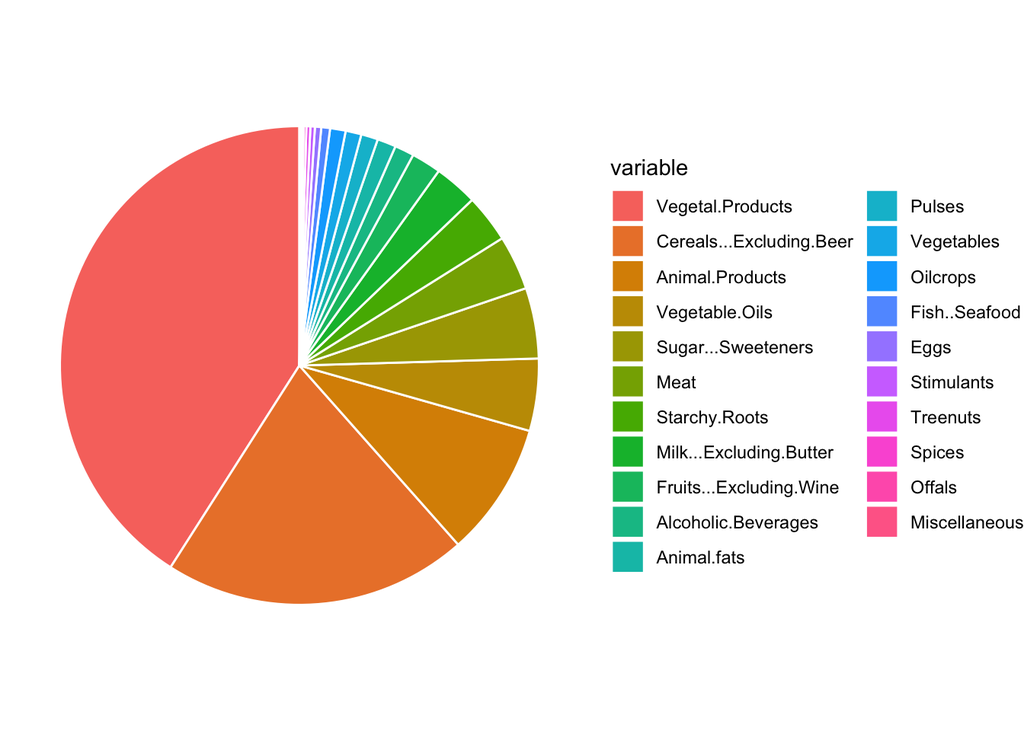

Figure1: Energy intake products

Pie chart shows that the vegetal products takes most part of the energy that people intake. Therefore, further analysis with vegetal products must be made in order to further analyze. In a following order, top 4 products takes about 75% of the total energy consumption.

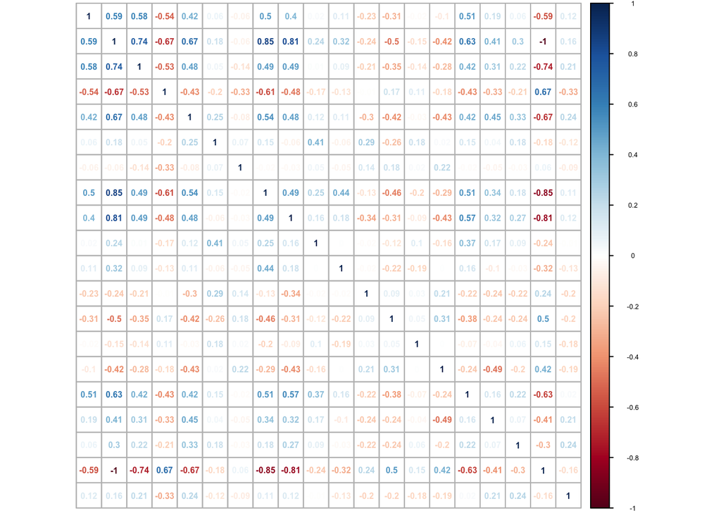

Figure2: Correlation Plot

The correlation plot further guides the method of analysis, which will be covered in later for detailed analysis.

In order to view the prior relationship of active COVID-19 rate and top 4 products that are taken into consideration of energy intake, 4 graphs were used.

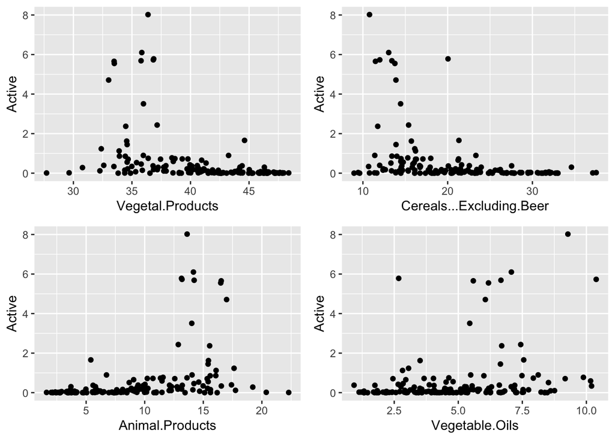

Figure3: Active vs Top 4 Energy intake products

From Figure 3, it is hard to analyze if there are any linear relationship among Active COVID cases and the products. Therefore further analysis is required.